# data_exploration

2025-03-18 12:08:24.117016

# 1 Moral Machines Experimental Paradigm

# 2 Exploration of methodology used in original study

```r
# Load up common functions from original paper
source("MMFunctionsShared.R")
```

## 2.1 AMCE

```r
# Original Paper's analysis of the main effects
# Take a small sample of ~100K paired rows instead of
# working with the full dataset due to size & memory constraints
df.small_profiles = fread(input="../../data/SharedResponses_small.csv")

profiles <- PreprocessProfiles(df.small_profiles)
```

```
[1] "Intervention"
[1] 0.05979025
[1] "Passengers"
[1] 0.0992845
[1] "Legality"
[1] 0.3496451
[1] "Gender"
[1] 0.1147693
[1] "Fitness"
[1] 0.1700065
[1] "Social Status"
[1] 0.1806308
[1] "Age"
[1] 0.5097648
[1] "Utilitarian"
[1] 0.4961741
[1] "Species"
[1] 0.5792044
```

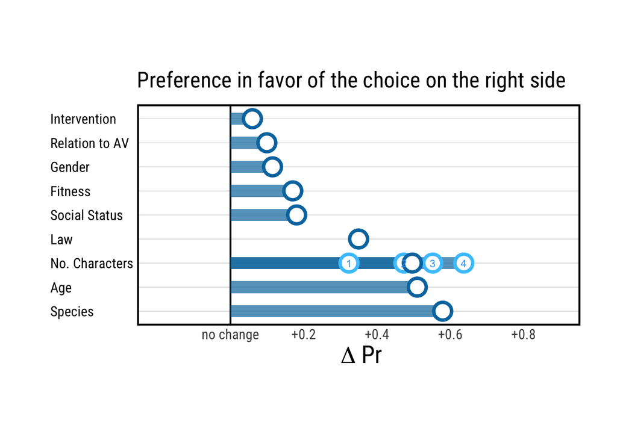

```r
# Main Figure 2 - (a)
Coeffs.main <- GetMainEffectSizes(profiles,T,9)
plotdata.main <- GetPlotData(Coeffs.main,T,9)

Coeffs.util <- GetMainEffectSizes.Util(profiles)
plotdata.util <- GetPlotData.Util(Coeffs.util)

## Save them
save(plotdata.main, file = "plotdatamain.rdata")
save(plotdata.util, file = "plotdatautil.rdata")
## Plot them
plot <- PlotAndSave(plotdata.main,T,"MainChangePr",plotdata.util)

# Show plot
plot
```

### 2.1.1 Own-self implementation of the analysis used (sanity-check)

```r
lev = levels(profiles$ScenarioType)
print(lev)

AttLevels = levels(profiles$AttributeLevel)
print(AttLevels)

# Focusing on the Age characteristic
df.age_profiles = profiles %>%
  filter(ScenarioType==lev[1] & profiles$ScenarioTypeStrict==lev[1]) %>%
  mutate(AttributeLevel = factor(AttributeLevel, levels=AttLevels[(4*2):(4*2+1)]))

df.age_profiles %>% head()

fit.age = lm(Saved ~ as.factor(AttributeLevel), data=df.age_profiles)

fit.age %>% tidy()
```

```
[1] "Age"           "Fitness"       "Gender"        "Random"
[5] "Social Status" "Species"       "Utilitarian"
 [1] "Rand"    "Male"    "Female"  "Fat"     "Fit"     "Low"     "High"
 [8] "Old"     "Young"   "Less"    "More"    "Pets"    "Hoomans"
      V1        ResponseID            ExtendedSessionID       UserID
   <int>            <char>                       <char>        <num>
1:     5 225WgrCaRocAft4Bz       144981315_3400506088.0 3.400506e+09
2:     6 225WgrCaRocAft4Bz       144981315_3400506088.0 3.400506e+09
3:    27 22Q464WHT72jk7oFY     -2104617679_3415840327.0 3.415840e+09
4:    28 22Q464WHT72jk7oFY     -2104617679_3415840327.0 3.415840e+09
5:    43 22dvbTaPdGnDBiQAv 506117758_4684690858173972.0 4.684691e+15
6:    44 22dvbTaPdGnDBiQAv 506117758_4684690858173972.0 4.684691e+15
   ScenarioOrder Intervention PedPed Barrier CrossingSignal AttributeLevel
           <int>       <fctr>  <int>  <fctr>         <fctr>         <fctr>
1:            11            0      0       1              0            Old
```

[output cut: 58 more lines]

```r
weights = df.age_profiles %>% calcWeightsTheoretical()
length(weights)
print(df.age_profiles %>% nrow())
```

```
[1] 33104
[1] 33104
```

So a single weight is computed for each row of profile data, let’s take a peek under the hood for this `calcWeightsTheoretical` function:

```r
# This returns the inverse probability (1/p) of the data distribution
calcWeightsTheoretical <- function(profiles){
  p <- apply(profiles,1,CalcTheoreticalInt)
  return(1/p)
}

# A-priori random generation probability constraints on some of the
# other attributes (Intervention, Barrier, PedPed, CrossingSignal).
# Which relates to the interaction between legality of crossing and
# whether there are passengers in the car.
CalcTheoreticalInt <- function(X){
  if (X["Intervention"]==0){
    if (X["Barrier"]==0){
      if (X["PedPed"] == 1) p <- 0.48
      else p <- 0.32

      if (X["CrossingSignal"]==0) p <- p*0.48
      else if (X["CrossingSignal"]==1) p <- p*0.2
      else p <- p * 0.32
    }
    else p <- 0.2
  }
  else {
    if (X["Barrier"]==0){
      if (X["PedPed"] == 1) {
        p <- 0.48
        if (X["CrossingSignal"]==0) p <- p*0.48
        else if (X["CrossingSignal"]==1) p <- p*0.32
        else p <- p * 0.2
      }
      else {
        p <- 0.2
        if (X["CrossingSignal"]==0) p <- p*0.48
        else if (X["CrossingSignal"]==1) p <- p*0.2
        else p <- p * 0.32
      }
    }
    else p <- 0.32
  }
  return(p)
}
```

Let’s incorporate these weights into our lm model:

```r
fit.age = lm(Saved ~ as.factor(AttributeLevel),
             data=df.age_profiles,
             weights=calcWeightsTheoretical(df.age_profiles))

fit.age %>% tidy()
```

```
# A tibble: 2 × 5
  term                           estimate std.error statistic p.value
  <chr>                             <dbl>     <dbl>     <dbl>   <dbl>
1 (Intercept)                       0.255   0.00335      76.3       0
2 as.factor(AttributeLevel)Young    0.510   0.00473     108.        0
```

```r
fit.logit_age = glm(Saved ~ as.factor(AttributeLevel),
                    data=df.age_profiles,
                    weights=calcWeightsTheoretical(df.age_profiles))

fit.logit_age %>% tidy()
```

```
# A tibble: 2 × 5
  term                           estimate std.error statistic p.value
  <chr>                             <dbl>     <dbl>     <dbl>   <dbl>
1 (Intercept)                       0.255   0.00335      76.3       0
2 as.factor(AttributeLevel)Young    0.510   0.00473     108.        0
```

## 2.3 brms bayesian analysis

```r
# Re-code CrossingSignal to be -1, 0, 1 with 0 as no legal
# -1 as illegal
# 1 as legal
profiles$CrossingSignal <- as.numeric(levels(profiles$CrossingSignal))[profiles$CrossingSignal]
profiles$CrossingSignal[profiles$CrossingSignal == 2] <- -1

profiles <- profiles %>%
  mutate(CrossingSignal = factor(CrossingSignal, levels=c(0, -1, 1)))
```

```r
# Focusing on the Age characteristic
df.age_profiles = profiles %>%
  filter(ScenarioType==lev[1] & profiles$ScenarioTypeStrict==lev[1]) %>%
  mutate(AttributeLevel = factor(AttributeLevel, levels=AttLevels[(4*2):(4*2+1)]),
         Barrier = factor(Barrier, levels=c(0, 1)),
         Intervene = factor(Intervention, levels=c(0, 1))) %>%
  select(-Intervention) %>%
  sample_n(10000)
```

```r
priors <- c(
  prior(normal(0, 1), class = Intercept),
  prior(normal(0, 1), class = b),
  prior(exponential(1), class = sd)
)

model_brms <- brm(
  bf(Saved ~ as.factor(Intervene) + Barrier + CrossingSignal + AttributeLevel + (1 | ResponseID)),
  data = df.age_profiles,
  family = bernoulli(link = "logit"),
  prior = priors,
  chains = 4, cores = 4, iter = 2000, seed = 1234
)
```

[output not shown]

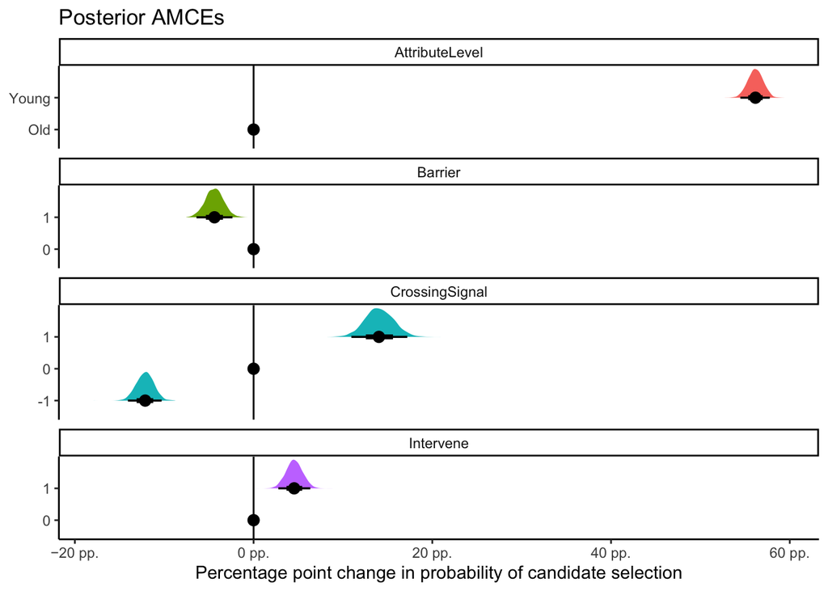

```r
posterior_mfx <- model_brms %>%
  avg_slopes(newdata = "mean", allow_new_levels = TRUE) %>%
  posterior_draws()

posterior_mfx_nested <- posterior_mfx %>%
  separate_wider_delim(
    contrast,
    delim = " - ",
    names = c("variable_level", "reference_level")
  ) %>%
  group_by(term, variable_level) %>%
  nest()

model_variable_levels <- tibble(
  variable = c("AttributeLevel", "Barrier", "CrossingSignal", "Intervene"),
  levels = list(factor(c("Old", "Young"), levels=c("Old", "Young")),
             factor(c(0, 1), levels=c(0, 1)),
             factor(c(-1, 0, 1), levels=c(0, -1, 1)),
             factor(c(0, 1), levels=c(0, 1))
  )) %>%
  unnest(levels)

# Combine full dataset of factor levels with model results
plot_data_bayes <- model_variable_levels %>%
  left_join(
    posterior_mfx_nested,
    by = join_by(variable == term, levels == variable_level)
  ) %>%
  mutate(data = map_if(data, is.null, ~ tibble(draw = 0, estimate = 0))) %>%
  unnest(data) # %>%
  # left_join(variable_lookup, by = join_by(variable)) %>%
  # mutate(across(c(levels, variable_nice), ~fct_inorder(.)))

label_pp <- label_number(accuracy = 1, scale = 100,
                         suffix = " pp.", style_negative = "minus")

ggplot(plot_data_bayes, aes(x = draw, y = levels, fill = variable)) +
  geom_vline(xintercept = 0) +
  stat_halfeye(normalize = "groups") +  # Make the heights of the distributions equal within each facet
  guides(fill = "none") +
  facet_col(facets = "variable", scales = "free_y", space = "free") +
  scale_x_continuous(labels = label_pp) +
  labs(
    x = "Percentage point change in probability of candidate selection",
    y = NULL,
    title = "Posterior AMCEs"
  )
```

## 2.4 Analysising the data using sum within slices & breakdown

A common data analysis technique is to slice the data by a particular subset of columns and values within those columns then apply SUM (or other metrics) to some measure column.

Which should then theoretically allow us to replicate all the above results without use of lm modeling by simply taking a ratio of `num_saved` / `total` for particular tuples of (Intervene, Barrier, CrossingSignal, AttributeLevel).

Furthermore, to analyze Intervene, Barrier, or CrossingSignal (invertention, passenger vs pedestrain, legality attributes), we can SUM again over different ScenarioTypes and AttributeLevels.

The key is to first precompute the sum of saved profiles and total number of profiles with different categorical levels of attributes.

```r
# Precompute categorical levels
df.agg_profiles = profiles %>%
  filter(ScenarioType == ScenarioTypeStrict) %>%
  group_by(Intervention, Barrier, CrossingSignal, PedPed, ScenarioType, AttributeLevel) %>%
  summarize(num_saved = sum(ifelse(Saved == 1, 1, 0)),
            total = n())
```

[output not shown]

```r
# Attempt to recover age-component causal effect
df.agg_profiles %>%
  filter(ScenarioType == "Age") %>%
  group_by(AttributeLevel) %>%
  summarize(porportion = sum(num_saved)/sum(total))
```

```
# A tibble: 2 × 2
  AttributeLevel porportion
  <fct>               <dbl>
1 Old                 0.234
2 Young               0.766
```

As a sanity check, the above two proportions sum to 1 (as expected).

This gives a difference of 0.5312954 when setting Old to be the baseline. Which is pretty accurate! Seeing as how we haven’t applied weighting to this and the original method returned 0.5097648.

To apply weighting to this, we would multiply the `num_saved` count by some inverse proportion of the total sum of other attributes.

```r
df.agg_profiles = df.agg_profiles %>%
  left_join(df.agg_profiles %>%
      group_by(Intervention, Barrier, CrossingSignal) %>%
      summarize(wsamples = sum(total)) %>%
      ungroup() %>%
      mutate(wtotal = sum(wsamples)) %>%
      mutate(wproportion = wsamples/wtotal) %>%
      mutate(weight = 1/wproportion)) %>%
  select(-wsamples,-wtotal,-wproportion)
# Try again weighted age-component causal effect
df.agg_profiles %>%
  filter(ScenarioType == "Age") %>%
  group_by(AttributeLevel) %>%
  mutate(weight_sum = sum(weight)) %>%
  summarize(porportion = sum(num_saved*(weight/weight_sum))/sum(total*(weight/weight_sum)))
```

```
# A tibble: 2 × 2
  AttributeLevel porportion
  <fct>               <dbl>
1 Old                 0.244
2 Young               0.765
```

Now the difference is 0.5215997.

The weight has slightly moderated the difference between the two levels, however, since I’m using the a posteriori weights (experimental distribution weights) instead of the a priori ones (theoretical ones), there is still some slight differences. Let’s try to fix that.

```r
df.agg_profiles['weight'] = calcWeightsTheoretical(df.agg_profiles)

# Try again weighted age-component causal effect
df.agg_profiles %>%
  filter(ScenarioType == "Age") %>%
  group_by(AttributeLevel) %>%
  mutate(weight_sum = sum(weight)) %>%
  summarize(porportion = sum(num_saved*(weight/weight_sum))/sum(total*(weight/weight_sum)))
```

```
# A tibble: 2 × 2
  AttributeLevel porportion
  <fct>               <dbl>
1 Old                 0.255
2 Young               0.765
```

This provides us a difference of 0.5097647 / which exactly recovers the original study’s computed average marginal causal effect without using lm but also without a measure of clustered errors.

Arel-Bundock, Vincent. 2025. *Marginaleffects: Predictions, Comparisons, Slopes, Marginal Means, and Hypothesis Tests*. https://marginaleffects.com/.

Arel-Bundock, Vincent, Noah Greifer, and Andrew Heiss. 2024. “How to Interpret Statistical Models Using marginaleffects for R and Python.” *Journal of Statistical Software* 111 (9): 1–32. https://doi.org/10.18637/jss.v111.i09.

Barari, Soubhik, Elissa Berwick, Jens Hainmueller, Daniel Hopkins, Sean Liu, Anton Strezhnev, and Teppei Yamamoto. 2023. *Cjoint: AMCE Estimator for Conjoint Experiments*. https://CRAN.R-project.org/package=cjoint.

Bates, Douglas, Martin Maechler, and Mikael Jagan. 2024. *Matrix: Sparse and Dense Matrix Classes and Methods*. https://Matrix.R-forge.R-project.org.

Bürkner, Paul-Christian. 2017. “brms: An R Package for Bayesian Multilevel Models Using Stan.” *Journal of Statistical Software* 80 (1): 1–28. https://doi.org/10.18637/jss.v080.i01.

———. 2018. “Advanced Bayesian Multilevel Modeling with the R Package brms.” *The R Journal* 10 (1): 395–411. https://doi.org/10.32614/RJ-2018-017.

———. 2021. “Bayesian Item Response Modeling in R with brms and Stan.” *Journal of Statistical Software* 100 (5): 1–54. https://doi.org/10.18637/jss.v100.i05.

———. 2024. *Brms: Bayesian Regression Models Using Stan*. https://github.com/paul-buerkner/brms.

Eddelbuettel, Dirk. 2013. *Seamless R and C++ Integration with Rcpp*. New York: Springer. https://doi.org/10.1007/978-1-4614-6868-4.

Eddelbuettel, Dirk, and James Joseph Balamuta. 2018. “Extending R with C++: A Brief Introduction to Rcpp.” *The American Statistician* 72 (1): 28–36. https://doi.org/10.1080/00031305.2017.1375990.

Eddelbuettel, Dirk, Romain Francois, JJ Allaire, Kevin Ushey, Qiang Kou, Nathan Russell, Iñaki Ucar, Doug Bates, and John Chambers. 2024. *Rcpp: Seamless r and c++ Integration*. https://www.rcpp.org.

Eddelbuettel, Dirk, and Romain François. 2011. “Rcpp: Seamless R and C++ Integration.” *Journal of Statistical Software* 40 (8): 1–18. https://doi.org/10.18637/jss.v040.i08.

Gerstenberg, Tobias, Matthew F. Peterson, Noah D. Goodman, David A. Lagnado, and Joshua B. Tenenbaum. 2017. “Eye-Tracking Causality.” *Psychological Science* 28 (12): 1731–44. https://doi.org/10.1177/0956797617713053.

Grolemund, Garrett, and Hadley Wickham. 2011. “Dates and Times Made Easy with lubridate.” *Journal of Statistical Software* 40 (3): 1–25. https://www.jstatsoft.org/v40/i03/.

Hothorn, Torsten, Achim Zeileis, Richard W. Farebrother, and Clint Cummins. 2022. *Lmtest: Testing Linear Regression Models*. https://CRAN.R-project.org/package=lmtest.

Kay, Matthew. 2024a. *Ggdist: Visualizations of Distributions and Uncertainty*. https://mjskay.github.io/ggdist/.

———. 2024b. “ggdist: Visualizations of Distributions and Uncertainty in the Grammar of Graphics.” *IEEE Transactions on Visualization and Computer Graphics* 30 (1): 414–24. https://doi.org/10.1109/TVCG.2023.3327195.

Lenth, Russell V. 2025. *Emmeans: Estimated Marginal Means, Aka Least-Squares Means*. https://rvlenth.github.io/emmeans/.

Lumley, Thomas. 2004. “Analysis of Complex Survey Samples.” *Journal of Statistical Software* 9 (1): 1–19.

———. 2010. *Complex Surveys: A Guide to Analysis Using r: A Guide to Analysis Using r*. John Wiley; Sons.

Lumley, Thomas, Peter Gao, and Ben Schneider. 2024. *Survey: Analysis of Complex Survey Samples*. http://r-survey.r-forge.r-project.org/survey/.

Müller, Kirill, and Hadley Wickham. 2023. *Tibble: Simple Data Frames*. https://tibble.tidyverse.org/.

Pedersen, Thomas Lin. 2024. *Ggforce: Accelerating Ggplot2*. https://ggforce.data-imaginist.com.

R Core Team. 2024. *R: A Language and Environment for Statistical Computing*. Vienna, Austria: R Foundation for Statistical Computing. https://www.R-project.org/.

Robinson, David, Alex Hayes, and Simon Couch. 2024. *Broom: Convert Statistical Objects into Tidy Tibbles*. https://broom.tidymodels.org/.

Spinu, Vitalie, Garrett Grolemund, and Hadley Wickham. 2024. *Lubridate: Make Dealing with Dates a Little Easier*. https://lubridate.tidyverse.org.

Terry M. Therneau, and Patricia M. Grambsch. 2000. *Modeling Survival Data: Extending the Cox Model*. New York: Springer.

Therneau, Terry M. 2024. *Survival: Survival Analysis*. https://github.com/therneau/survival.

Wickham, Hadley. 2016. *Ggplot2: Elegant Graphics for Data Analysis*. Springer-Verlag New York. https://ggplot2.tidyverse.org.

———. 2023a. *Forcats: Tools for Working with Categorical Variables (Factors)*. https://forcats.tidyverse.org/.

———. 2023b. *Stringr: Simple, Consistent Wrappers for Common String Operations*. https://stringr.tidyverse.org.

———. 2023c. *Tidyverse: Easily Install and Load the Tidyverse*. https://tidyverse.tidyverse.org.

Wickham, Hadley, Mara Averick, Jennifer Bryan, Winston Chang, Lucy D’Agostino McGowan, Romain François, Garrett Grolemund, et al. 2019. “Welcome to the tidyverse.” *Journal of Open Source Software* 4 (43): 1686. https://doi.org/10.21105/joss.01686.

Wickham, Hadley, Winston Chang, Lionel Henry, Thomas Lin Pedersen, Kohske Takahashi, Claus Wilke, Kara Woo, Hiroaki Yutani, Dewey Dunnington, and Teun van den Brand. 2024. *Ggplot2: Create Elegant Data Visualisations Using the Grammar of Graphics*. https://ggplot2.tidyverse.org.

Wickham, Hadley, Romain François, Lionel Henry, Kirill Müller, and Davis Vaughan. 2023. *Dplyr: A Grammar of Data Manipulation*. https://dplyr.tidyverse.org.

Wickham, Hadley, and Lionel Henry. 2023. *Purrr: Functional Programming Tools*. https://purrr.tidyverse.org/.

Wickham, Hadley, Jim Hester, and Jennifer Bryan. 2024. *Readr: Read Rectangular Text Data*. https://readr.tidyverse.org.

Wickham, Hadley, Thomas Lin Pedersen, and Dana Seidel. 2023. *Scales: Scale Functions for Visualization*. https://scales.r-lib.org.

Wickham, Hadley, Davis Vaughan, and Maximilian Girlich. 2024. *Tidyr: Tidy Messy Data*. https://tidyr.tidyverse.org.

Xie, Yihui. 2014. “Knitr: A Comprehensive Tool for Reproducible Research in R.” In *Implementing Reproducible Computational Research*, edited by Victoria Stodden, Friedrich Leisch, and Roger D. Peng. Chapman; Hall/CRC.

———. 2015. *Dynamic Documents with R and Knitr*. 2nd ed. Boca Raton, Florida: Chapman; Hall/CRC. https://yihui.org/knitr/.

———. 2024. *Knitr: A General-Purpose Package for Dynamic Report Generation in r*. https://yihui.org/knitr/.

Zeileis, Achim. 2004. “Econometric Computing with HC and HAC Covariance Matrix Estimators.” *Journal of Statistical Software* 11 (10): 1–17. https://doi.org/10.18637/jss.v011.i10.

———. 2006. “Object-Oriented Computation of Sandwich Estimators.” *Journal of Statistical Software* 16 (9): 1–16. https://doi.org/10.18637/jss.v016.i09.

Zeileis, Achim, and Gabor Grothendieck. 2005. “Zoo: S3 Infrastructure for Regular and Irregular Time Series.” *Journal of Statistical Software* 14 (6): 1–27. https://doi.org/10.18637/jss.v014.i06.

Zeileis, Achim, Gabor Grothendieck, and Jeffrey A. Ryan. 2025. *Zoo: S3 Infrastructure for Regular and Irregular Time Series (z’s Ordered Observations)*. https://zoo.R-Forge.R-project.org/.

Zeileis, Achim, and Torsten Hothorn. 2002. “Diagnostic Checking in Regression Relationships.” *R News* 2 (3): 7–10. https://CRAN.R-project.org/doc/Rnews/.

Zeileis, Achim, Susanne Köll, and Nathaniel Graham. 2020. “Various Versatile Variances: An Object-Oriented Implementation of Clustered Covariances in R.” *Journal of Statistical Software* 95 (1): 1–36. https://doi.org/10.18637/jss.v095.i01.

Zeileis, Achim, and Thomas Lumley. 2024. *Sandwich: Robust Covariance Matrix Estimators*. https://sandwich.R-Forge.R-project.org/.